# Analyzing Incarceration in the United States According to Geographic Location

Melanie Kuo

2022-11-01

## Abstract

Analysis of U.S. incarceration system, with a close look at the impact of geographical location factors. This report also includes data regarding the increase in population across the U.S., as well as analyzing the impact that geographic location has on jail populations, juvenile jail populations, and ICE jail populations.

## Introduction

This report will analyze incarceration across the United States, according to data from the Vera Institute. Currently, there are many issues surrounding incarceration in this country, including the disproportional impact of BIPOC individuals or geographically based – meaning that the rate at which one could be in jail or in prison would be higher due to factors like race or where they live. Indirect stakeholders include all individuals across the U.S., families of those in the jail system, as well as those in positions of power to achieve justice in the U.S. jail system, such as government officials and leaders. Additionally, those in the jail system are direct stakeholders for this research. In this report, I will focus on the factor of geographic location and analyze the following questions:

- Analyze the county with the highest jail population. What is the correlation between counties and jail population, and why might this be?
- What states in the United States have the highest jail population, and why might this be?
- What areas of the country have the highest juvenile jail population, and why might this be?
- What areas of the country have highest jail population from ICE, and why might this be?

## Data Summary

I also did some additional calculations to supplement my findings! According to the dataset, the U.S. county with the highest total jail population is Los Angeles County, and the geographic region with the highest total jail population is the West region. (This was in line with California having the highest jail population of all states). I also wanted to determine this geographic factor with juvenile incarceration rates, which were determined to be Buncombe County for highest female juvenile incarceration rates and New York County for highest male juvenile incarceration rates.

Considering geographic location is an important step in determining inequality in the prison system. Areas of higher affluence may have lower rates of incarceration, which puts those of higher class at a position of power, affecting individuals solely based off where they reside. Additionally, geographic location is tied to other factors that may be of influence, such as educational resources or homelessness. These observations helped begin the demonstration of interconnection between power in the U.S. prison system.

## Section 3 | Jail Population Increase

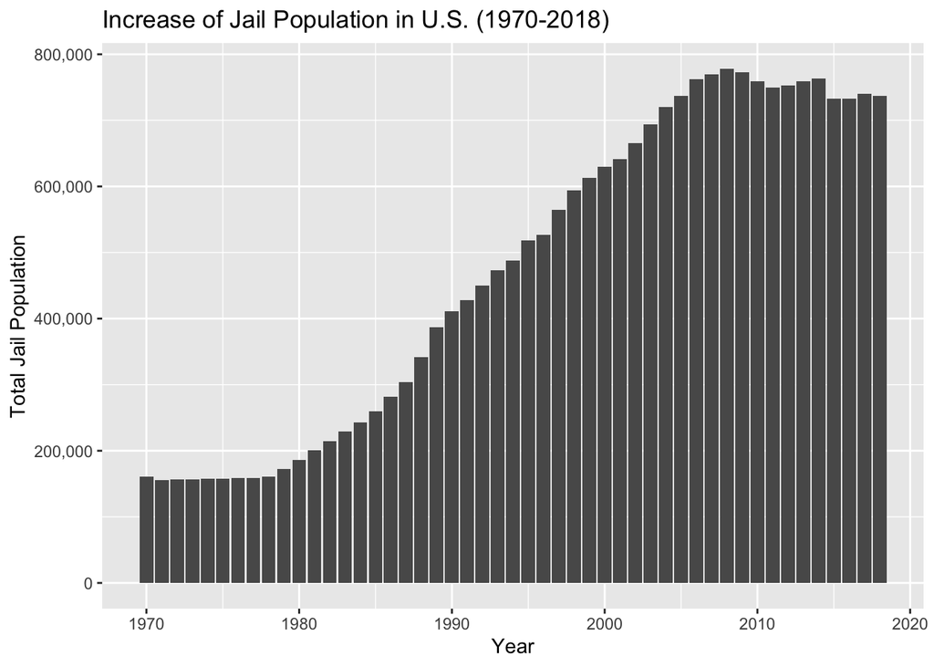

This visualization shows the increase of the U.S. jail population over time from 1970 to 2018.

**How has the U.S. jail population changed over time from 1970 to 2018?** From the chart, one can determine that the jail population in the United States has increased significantly between 1970 and 2018. It’s important to consider reasons for this jail population growth, such as an overall increase in the general population of the country. However, it is evident that the amount of people in jail has experienced growth over time.

## Section 4 | Growth of Jail Populations by State

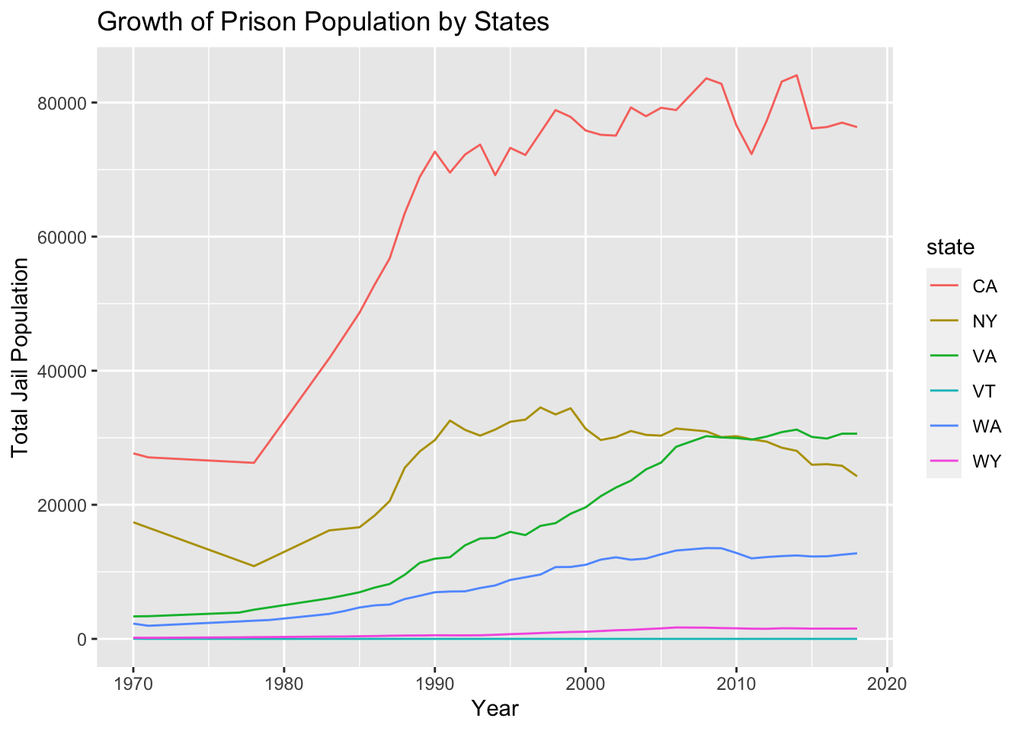

This visualization shows the jail population of 6 states (Washington, California, Wyoming, Vermont, Virginia, and New York) from 1970 to 2018.

**How have jail populations increased in specific states in the West and East/Northeast regions?** According to the chart, California has historically had the highest rate of growth for their jail population, acclimating greatly between 1980 and 1990. The next highest states are followed by New York and Virginia, the latter of which currently has the higher pattern of growth in jail population rate. Lastly, the rate includes Washington, followed by Vermont and Wyoming with the lowest jail populations. I chose these states specifically because I wanted to compare the rates of jail population between the West and East/Northeast regions. California and New York are two of the country’s two most populous states, so I decided to compare states on the West Coast with states on the East Coast that had a similar overall population. This data demonstrates that generally, the west has a higher rate of jail population, but this may be a factor due in part to California’s significant population compared to all other states.

## Section 5 | Growth of Juvenile Jail Population by State

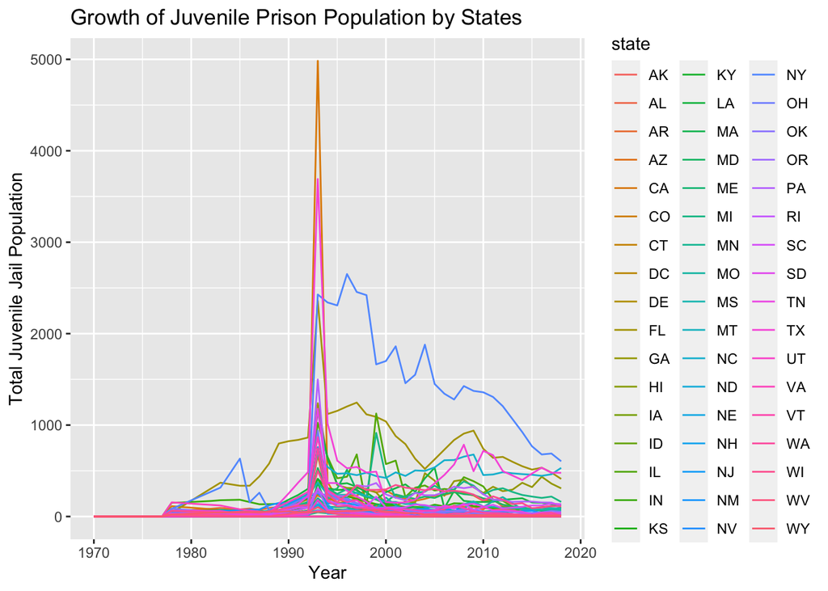

This chart demonstrates the growth of juvenile jail populations (both male and female) across every state.

## Section 6 | Total Jail Population from ICE Across the Country

[figure not shown]

**What impact does geographic location have on jail population from ICE?** *Based off the dataset, one can determine that certain states have higher rates of jail population by ICE.* Though the map was unable to populate with ICE data, the `incar_data` dataset demonstrated the top values of ICE jail rates were primarily in the South region of the United States. Amongst the top ten counties for ICE jail rates in 2016, Texas counties held three spots, and southern states like California, Georgia, Florida, and New Mexico were also in the top 10. This demonstrates that those in the southern U.S. regions are unfortunately more likely to be jailed due to ICE. This causation may be due in part to proximity to international borders, including Mexico. The 2016 filtering of this dataset was chosen to reflect the impact of ICE jailings from the Trump Administration, which had increased during this year (According to https://www.ice.gov/sites/default/files/documents/Report/2016/removal-stats-2016.pdf). This visualization allowed the analysis of injustices in the ICE immigration system.